# Inference interractions

# Note

Please, click on this link to get back to the Home Page.

# Packages & data

```r
# Packages

## Models library(alien)
library(ade4)
library(Hmsc)
library(boral)
library(ecoCopula)
library(PLNmodels)
library(EMtree)
library(MInt)
library(MRFcov)
library(gllvm)

## Graph
library(ggraph)
library(tidygraph)

## Plots
library(lattice)
library(corrplot)
library(gclus)
library(viridis)

# Data

# load('Faune_cleaned_06-09-18.RData') # Not in use right now

## seed

set.seed(42)
```

# Testing packages

## Hmsc

### Generating simulated data

```r
n <- 100  # Number of data points
x1 <- rnorm(n)  # Covariate 1
x2 <- rnorm(n)  # Covariate 2
XData <- data.frame(x1 = x1, x2 = x2)  # Covariates

# True parameters for slope and covariates
alpha <- c(0, 0, 0, 0, 0)
beta1 <- c(1, 1, -1, -1, 0)
beta2 <- c(1, -1, 1, -1, 0)
sigma <- c(1, 1, 1, 1, 1)

L <- matrix(NA, nrow = n, ncol = 5)  # Matrix of linear predictors
Y <- matrix(NA, nrow = n, ncol = 5)  # Matrix of generated data

for (j in 1:5) {
    L[, j] <- alpha[j] + beta1[j] * x1 + beta2[j] * x2
    Y[, j] <- L[, j] + rnorm(n, sd = sigma[j])
}
```

### Estimating responses

```r
studyDesign <- data.frame(sample = as.factor(1:n))

rL <- HmscRandomLevel(units = studyDesign$sample)

m <- Hmsc(Y = Y, XData = XData, XFormula = ~x1 + x2, studyDesign = studyDesign, ranLevels = list(sample = rL))
```

### Setting up MCMC sampling

```r
nChains <- 3
thin <- 1
samples <- 1000
transient <- 500 * thin
verbose <- 1
```

### Sampling

```r
if (parallel::detectCores() > 2 & parallel::detectCores() > nChains) {

    nParallel <- nChains

} else {

    nParallel <- 1

}

m <- sampleMcmc(m, thin = thin, samples = samples, transient = transient, nChains = nChains,
    verbose = 1, nParallel = nParallel)
```

### Diagnostic of the model

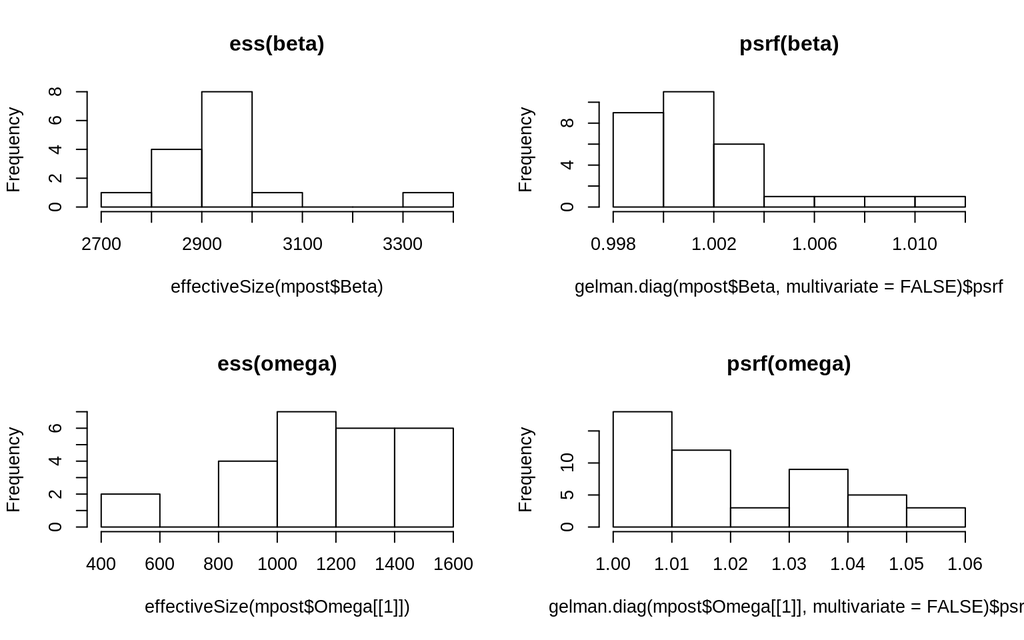

```r
mpost <- convertToCodaObject(m)

par(mfrow = c(2, 2))

hist(effectiveSize(mpost$Beta), main = "ess(beta)")
hist(gelman.diag(mpost$Beta, multivariate = FALSE)$psrf, main = "psrf(beta)")
hist(effectiveSize(mpost$Omega[[1]]), main = "ess(omega)")
hist(gelman.diag(mpost$Omega[[1]], multivariate = FALSE)$psrf, main = "psrf(omega)")
```

### $\beta$ estimation

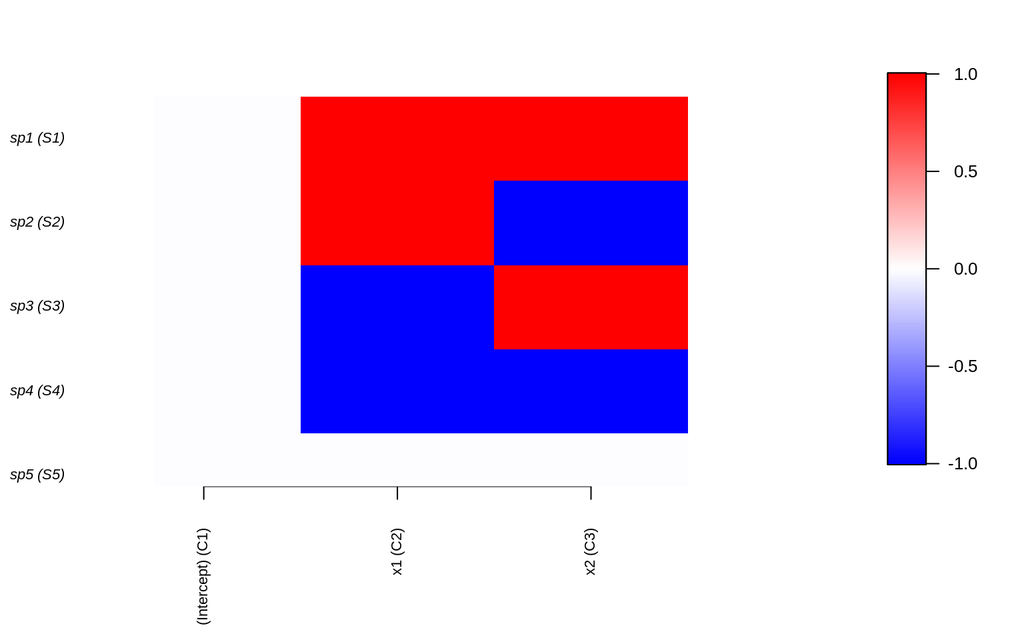

```r
postBeta = getPostEstimate(m, parName = "Beta")
plotBeta(m, post = postBeta, param = "Support", supportLevel = 0.95)
```

At $\alpha$ threshold $0.05$, We see that species 1 and 2 respond positively and species 3 and 4 respond negatively to covariable 1. Species 1 and 3 response positively to covaribale 2. Species 5 do not respond with these two variables. Estimate of intercept is of less interest because it’s related to the mean abundance of each species.

### $\Omega$ estimation

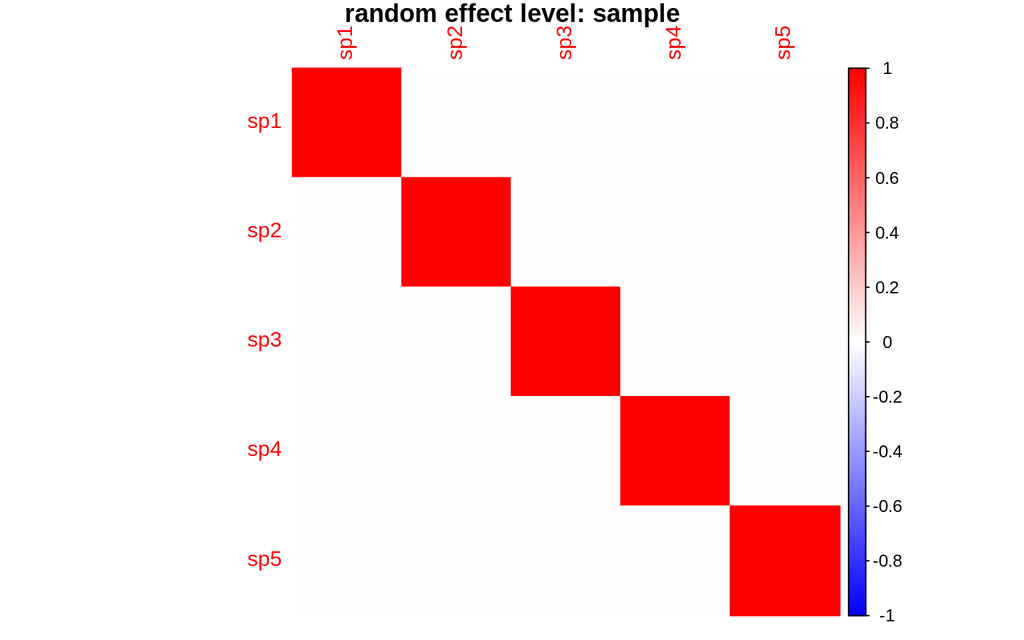

```r
OmegaCor <- computeAssociations(m)
supportLevel <- 0.95

toPlot <- ((OmegaCor[[1]]$support > supportLevel) + (OmegaCor[[1]]$support < (1 -
    supportLevel)) > 0) * OmegaCor[[1]]$mean

corrplot(toPlot, method = "color", col = colorRampPalette(c("blue", "white", "red"))(200),
    title = paste("random effect level:", m$rLNames[1]), mar = c(0, 0, 1, 0))
```

We only see intraspecifics associations because, when we generated the data, whe simulated the residuals independently for each species. In general, residual associations among species can be generated by correlated responses to missing covariates, or by ecological interactions.

### Explanatory & predictive power

```r
preds <- computePredictedValues(m)
evaluateModelFit(hM = m, predY = preds)
```

```
$RMSE
[1] 0.9787161 0.8509446 0.9739604 1.0102608 0.9492561

$R2
[1] 0.6573532 0.7326553 0.6149546 0.7116126 0.1429728
```

$R^2$ is the explanatory power, poor for specie 5. RMSE is close to $1$, because we simulated data with a $\sigma = 1$. If we want to know the predictive power, we need to use CV technics.

```r
partition <- createPartition(m, nfolds = 2)
preds <- computePredictedValues(m, partition = partition, nParallel = nParallel)

evaluateModelFit(hM = m, predY = preds)
```

[output not shown]

### Variance partitionning

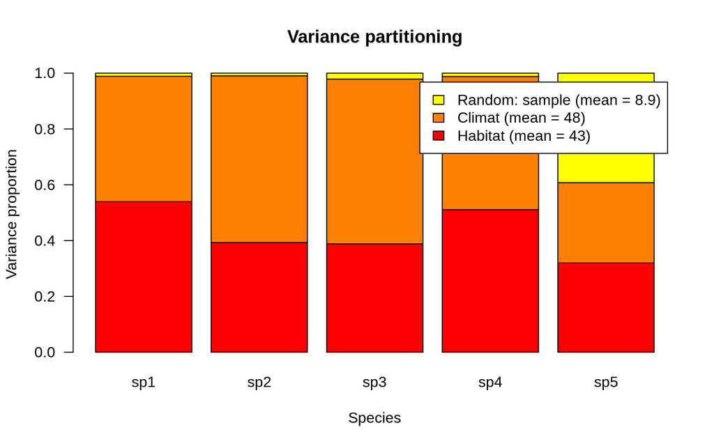

```r
VP <- computeVariancePartitioning(m, group = c(1, 2), groupnames = c("Habitat", "Climat"))

plotVariancePartitioning(m, VP)
```

When performing a variance partitioning, we can group the fixed effects (i.e., the columns of the design matrix `head(m$X)`).

### Traits

It is possible to use traits data, we need to specify a trait coefficient

## boral

I won’t try *boral* right know, because *gllvm* seem to be much faster.

## gllvm

### Data loading

```r
data("antTraits")

y <- antTraits$abund

X <- scale(antTraits$env)

TR <- antTraits$traits
```

### Model fitting

```r
criterias4th <- NULL

for (i in 0:5) {

    fiti <- gllvm(y, X, TR, family = "negative.binomial", num.lv = i, formula = y ~
        (Bare.ground + Shrub.cover + Volume.lying.CWD) + (Bare.ground + Shrub.cover +
            Volume.lying.CWD):(Pilosity + Polymorphism + Webers.length), seed = 1234)

    criterias4th[i + 1] <- summary(fiti)$AICc

    names(criterias4th)[i + 1] = i
}

print(criterias4th)
```

```
       0        1        2        3        4        5
3817.289 3710.561 3679.402 3662.920 3666.917 3686.277
```

Based on *AIC*, we should choose 3 latent variables.

```r
fit_4th <- gllvm(y, X, TR, family = "negative.binomial", num.lv = 3, formula = y ~
    (Bare.ground + Shrub.cover + Volume.lying.CWD) + (Bare.ground + Shrub.cover +
        Volume.lying.CWD):(Pilosity + Polymorphism + Webers.length))
```

### Diagnostic plot

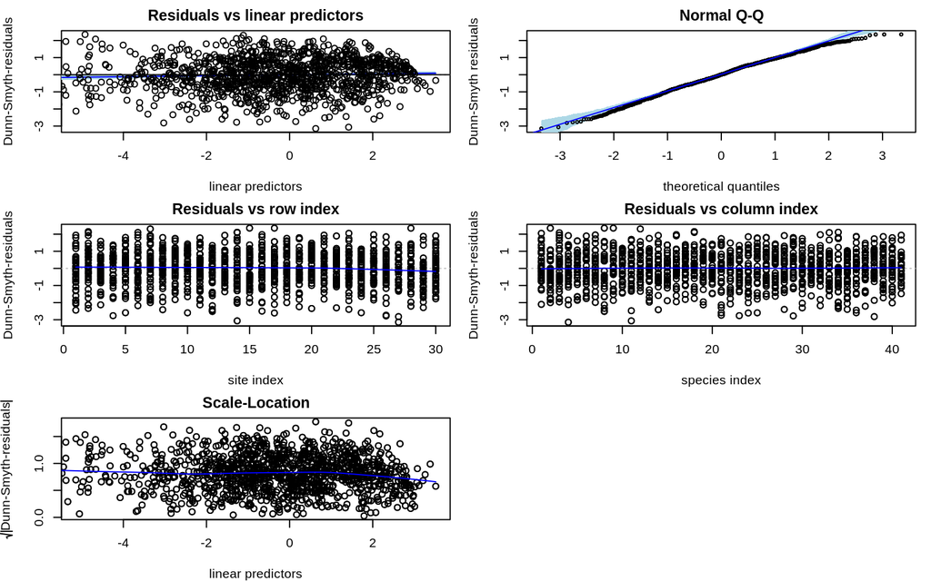

```r
par(mfrow = c(3, 2), mar = c(4, 4, 2, 1))
plot(fit_4th, var.colors = 1)
```

### Species association matrix

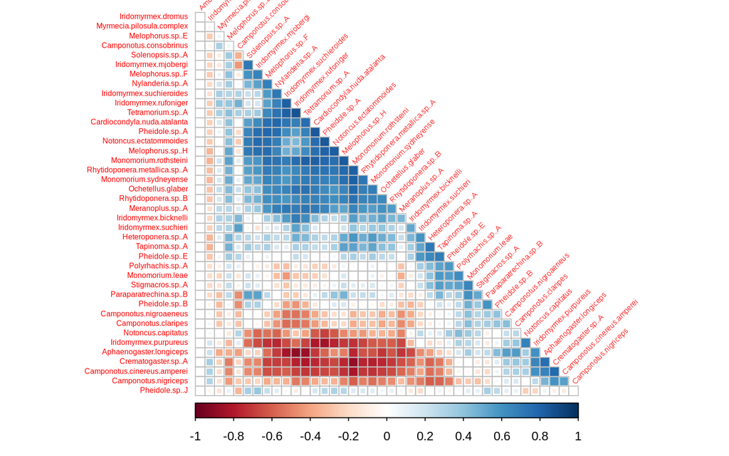

```r
cr0 <- getResidualCor(fit_4th)

corrplot(cr0[order.single(cr0), order.single(cr0)], diag = FALSE, type = "lower",
    method = "square", tl.cex = 0.5, tl.srt = 45, tl.col = "red")
```

Regions coloured in dark blue in correlation plot indicate clusters of species that are positively correlated with each other and regions coloured in dark red indicate negative correlation between pairs of species, after controlling for (co)variation in species explained by environmental terms.

### Environmental effect

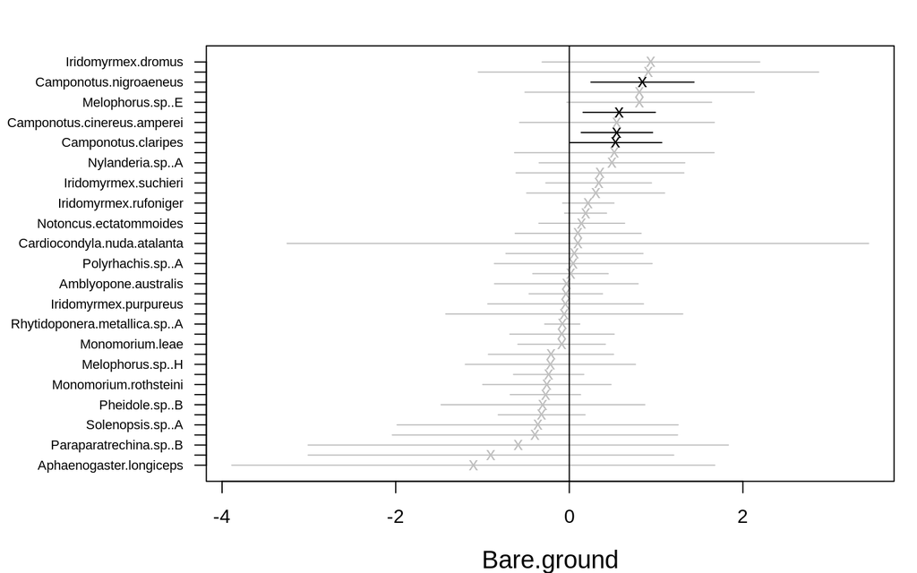

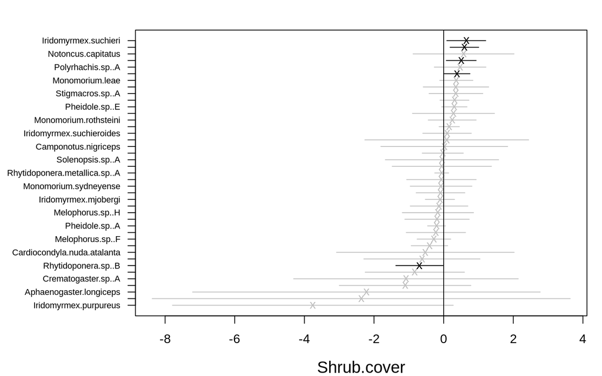

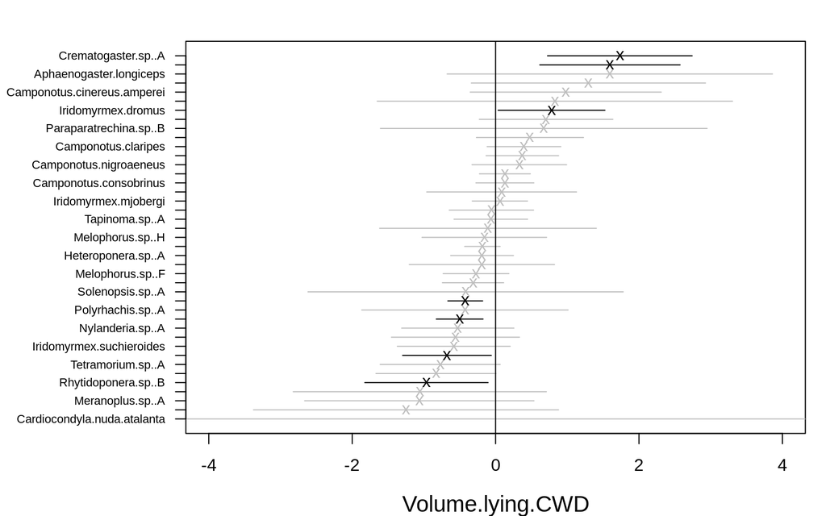

```r
fit_env <- gllvm(y, X, family = "negative.binomial", num.lv = 3, formula = ~Bare.ground +
    Shrub.cover + Volume.lying.CWD)

coefplot(fit_env, cex.ylab = 0.7, mar = c(4, 9, 2, 1), xlim.list = list(NULL, NULL,
    c(-4, 4)), mfrow = c(1, 1))
```

### Environmental-trait interraction

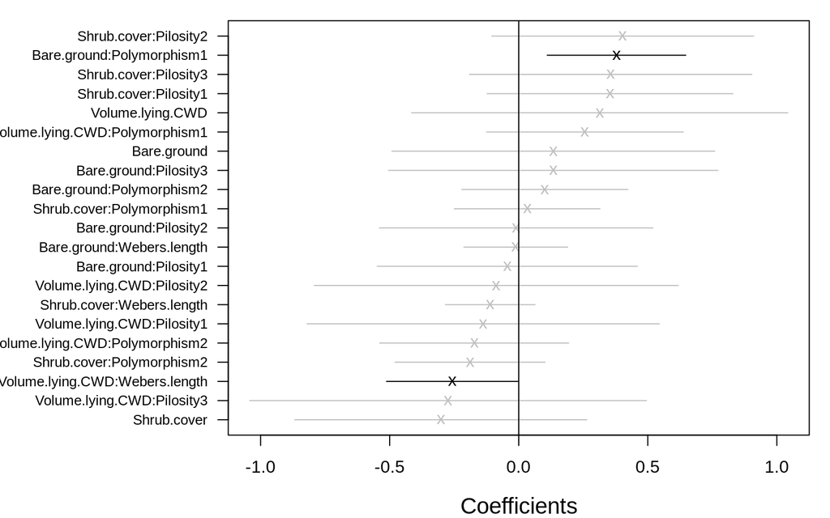

```r
coefplot(fit_4th, mar = c(4, 11, 1, 1), cex.ylab = 0.8)
```

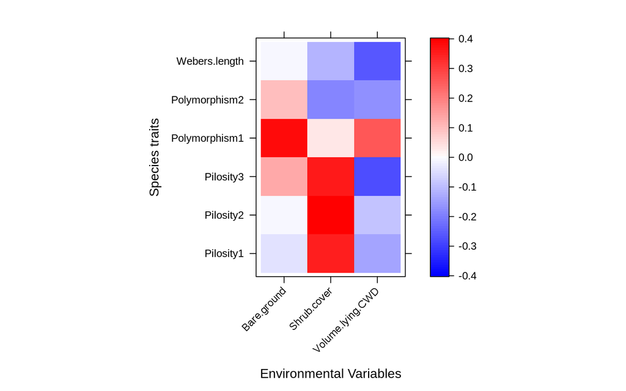

```r
fourth <- fit_4th$fourth.corner

a <- max(abs(fourth))

colort <- colorRampPalette(c("blue", "white", "red"))
plot.4th <- levelplot((as.matrix(fourth)), xlab = "Environmental Variables", ylab = "Species traits",
    col.regions = colort(100), cex.lab = 1.3, at = seq(-a, a, length = 100), scales = list(x = list(rot = 45)))
plot.4th
```

## ecoCopula

### Data

```r
data("spider")

abund <- mvabund(spider$abund)
X <- spider$x
```

### Model fitting & plot

This kind of model ignore traits data.

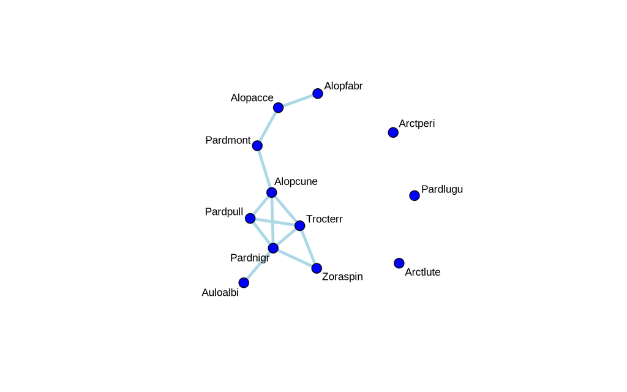

```r
spider_mod <- manyglm(abund ~ X)
spid_graph <- cgr(spider_mod)

plot(spid_graph, pad = 1)
```

## Emtree

### Data

I will use the same data as abose.

### Model fitting

```r
model <- PLN(abund ~ X)
```

```
 Initialization...
 Adjusting a PLN model with full covariance model
 Post-treatments...
 DONE!
```

```
Likelihoods: 28.11924 , 28.1714 , 28.17146 ,
```

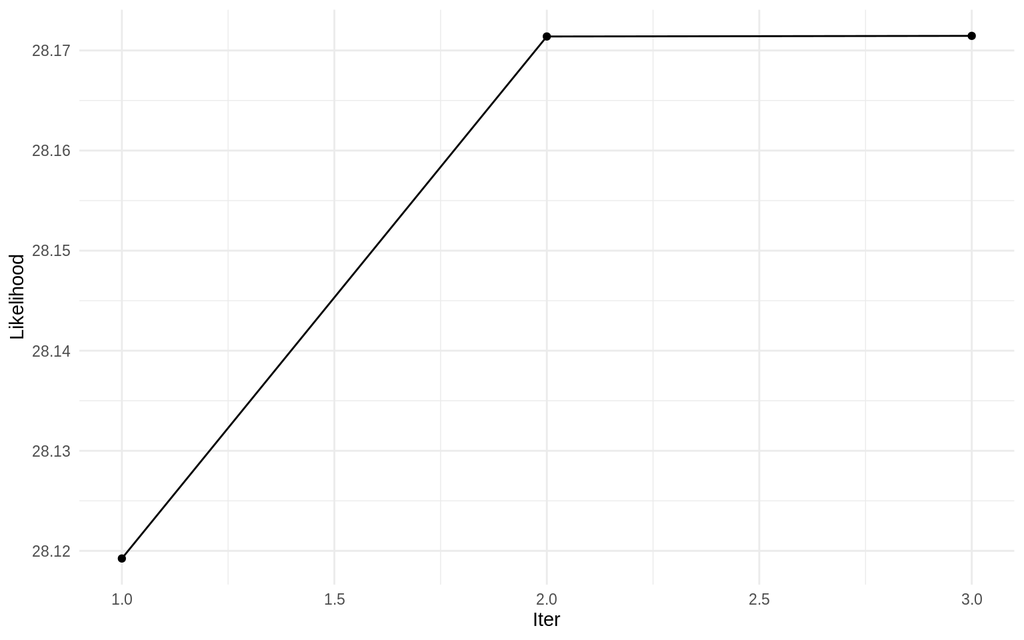

```
Convergence took 0.28 secs  and  3  iterations.
Likelihood difference = 6.023104e-05
Betas difference = 8.202454e-08
```

```r
p <- ncol(abund)  # Number of nodes

output <- EMtree(model, maxIter = 10, plot = TRUE)
```

```r
str(output)
```

```
List of 5
 $ edges_prob  : num [1:12, 1:12] 0 0.27858 0.00813 0.14115 0.05177 ...
 $ edges_weight: num [1:12, 1:12] 0 0.00761 0.00753 0.00757 0.00754 ...
 $ logpY       : num [1:3] 28.1 28.2 28.2
 $ maxIter     : num 3
 $ timeEM      : 'difftime' num 0.276307582855225
  ..- attr(*, "units")= chr "secs"
```

### Results

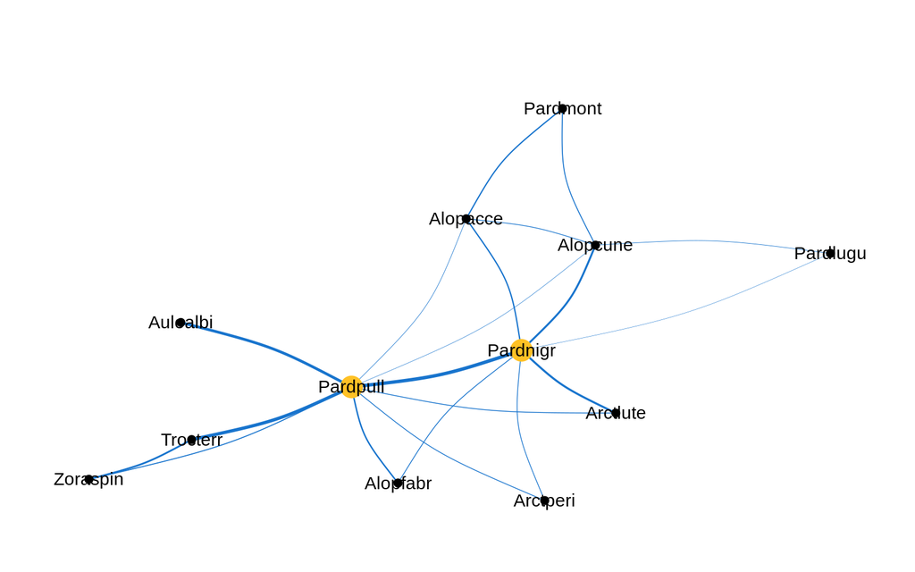

```
$graph_data
# A tbl_graph: 12 nodes and 20 edges
#
# An undirected simple graph with 1 component
#
# Node Data: 12 x 8 (active)
    btw bool_btw bool_deg   deg title name     label    finalcolor
  <dbl> <lgl>    <lgl>    <dbl> <chr> <chr>    <chr>    <lgl>
1     4 FALSE    TRUE         4 ""    Alopacce Alopacce FALSE
2     5 FALSE    TRUE         5 ""    Alopcune Alopcune FALSE
3     0 FALSE    TRUE         2 ""    Alopfabr Alopfabr FALSE
4     0 FALSE    TRUE         2 ""    Arctlute Arctlute FALSE
5     0 FALSE    TRUE         2 ""    Arctperi Arctperi FALSE
6     0 FALSE    TRUE         1 ""    Auloalbi Auloalbi FALSE
# … with 6 more rows
#
# Edge Data: 20 x 6
   from    to weight btw.weights neibs title
  <int> <int>  <dbl>       <dbl> <lgl> <chr>
1     1     2  0.279        1.52 FALSE ""
2     1     8  0.429        1.20 FALSE ""
3     1     9  0.437        1.19 TRUE  ""
# … with 17 more rows
```

```r
edges_prob <- output$edges_prob
edges_prob[edges_prob < 2/p] <- 0

EMtree::draw_network(edges_prob, nodes_label = colnames(abund), pal = "dodgerblue3",
    layout = "nicely", curv = 0.1)
```

## MInt

I don’t think I will use this package, I don’t understand how to use it.

```r
dFile <- system.file("extdata", "x.txt", package = "MInt")

rFile <- system.file("extdata", "y.txt", package = "MInt")

m <- mint(y = rFile, x = dFile, fmla = ~feature1 + feature2)

m <- estimate(m)  # Partial correlation matrix
```

[output not shown]

## MRFcov

### Data

I will use `abund` dataset.

### Model fitting

To fit *Conditional Random Fields* (a case *Markov Random Fields* with covariables), we need to `cbind()` faunistic data and covariables (using `n_nodes` to specify the last index of abundance column).

```r
MRF_fit <- MRFcov(data = cbind(abund, scale(X)), n_nodes = 12, n_cores = nParallel,
    family = "poisson")
```

```
Poisson variables will be transformed using a nonparanormal...
Fitting MRF models in sequence using 1 core ...
```

### Results

The heatmap represent predicted interaction when all the covariates are set to their mean (here, it is $0$).

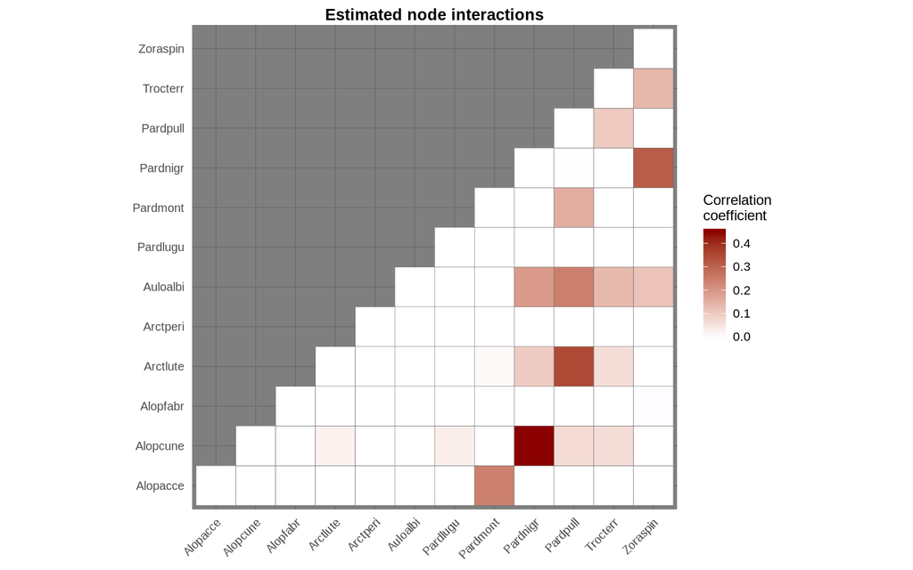

```r
plotMRF_hm(MRF_mod = MRF_fit)
```

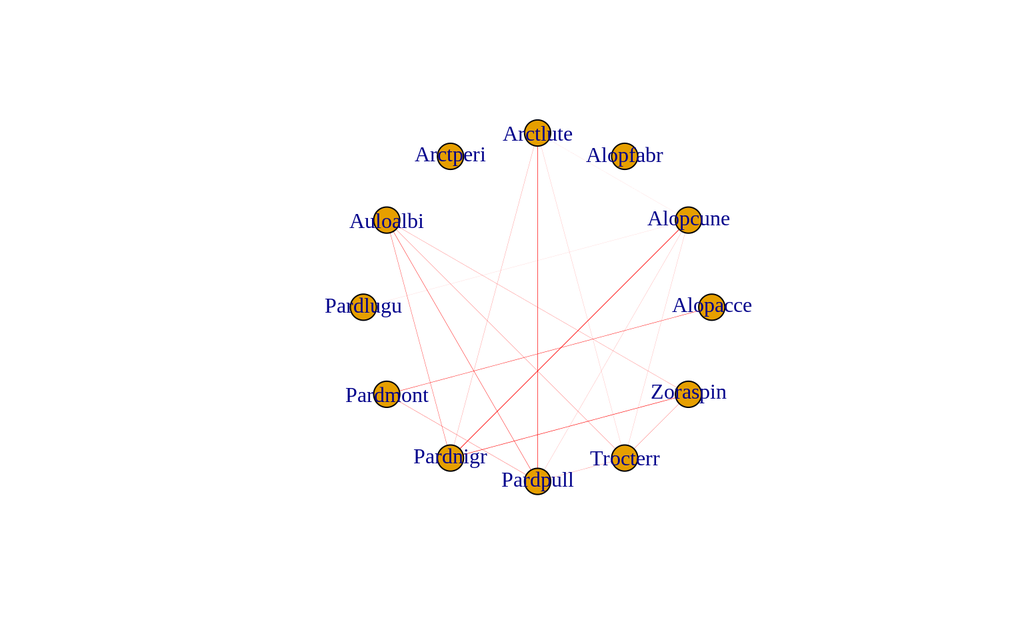

```r
net <- igraph::graph.adjacency(MRF_fit$graph, weighted = T, mode = "undirected")

igraph::plot.igraph(net, layout = igraph::layout.circle, edge.width = abs(igraph::E(net)$weight),
    edge.color = ifelse(igraph::E(net)$weight < 0, "blue", "red"))
```

We can see regression coefficients by using this piece of code

```r
MRF_fit$key_coefs
```

```
$Alopacce
           Variable Rel_importance Standardised_coef   Raw_coef
2          soil.dry     0.49855627        -0.4043430 -0.4043430
3        reflection     0.27845574         0.3021836  0.3021836
1          Pardmont     0.18016089         0.2430654  0.2430654
4 soil.dry_Pardmont     0.03108908         0.1009710  0.1009710

$Alopcune
             Variable Rel_importance Standardised_coef   Raw_coef
1            Pardnigr     0.87030630        0.44997336 0.44997336
4 reflection_Arctlute     0.07330643        0.13059356 0.13059356
2            Pardpull     0.01925366        0.06692793 0.06692793
3            Trocterr     0.01751362        0.06383204 0.06383204

$Alopfabr
    Variable Rel_importance Standardised_coef   Raw_coef
2  bare.sand      0.5584939         0.2263587  0.2263587
3 reflection      0.2436198         0.1495011  0.1495011
1   soil.dry      0.1975800        -0.1346355 -0.1346355

$Arctlute
                Variable Rel_importance Standardised_coef    Raw_coef
2               Pardpull     0.59529001        0.34636537  0.34636537
4      soil.dry_Pardmont     0.08991478        0.13461260  0.13461260
9    reflection_Alopcune     0.08462588        0.13059356  0.13059356
5 fallen.leaves_Pardpull     0.07335591       -0.12158716 -0.12158716
1               Pardnigr     0.04542672        0.09568103  0.09568103
7          moss_Pardpull     0.04345230       -0.09357860 -0.09357860
3               Trocterr     0.01930913        0.06238088  0.06238088
6          moss_Pardmont     0.01903890       -0.06194284 -0.06194284
8    herb.layer_Pardnigr     0.01408339        0.05327503  0.05327503

$Arctperi
  Variable Rel_importance Standardised_coef   Raw_coef
1 soil.dry              1        -0.1839355 -0.1839355

$Auloalbi
       Variable Rel_importance Standardised_coef    Raw_coef
2      Pardpull     0.40431595        0.24423216  0.24423216
1      Pardnigr     0.24494107        0.19009611  0.19009611
```

[output cut: 44 more lines]

```
3                Auloalbi     0.14474801        0.13056590  0.13056590
6                soil.dry     0.11993421        0.11884885  0.11884885
4                Pardpull     0.08432061        0.09965299  0.09965299
10          moss_Zoraspin     0.06119987        0.08489825  0.08489825
1                Alopcune     0.03459637        0.06383204  0.06383204
2                Arctlute     0.03304122        0.06238088  0.06238088
8      bare.sand_Alopcune     0.01003342        0.03437542  0.03437542

$Zoraspin
       Variable Rel_importance Standardised_coef    Raw_coef
2      Pardnigr     0.56979385        0.31275939  0.31275939
4    reflection     0.20329562       -0.18681661 -0.18681661
3      Trocterr     0.10814434        0.13625529  0.13625529
1      Auloalbi     0.07397210        0.11269002  0.11269002
5 moss_Trocterr     0.04198503        0.08489825  0.08489825
```

2020-01-17